# Solvers in Python

Prof. Daniel P. Palomar

Python code: [Zé Vinícius](https://github.com/mirca) IEDA/ELEC3180 - Data-Driven Portfolio Optimization The Hong Kong University of Science and Technology (HKUST) Spring 2022-23

This Python session will introduce different solvers in Python that can be used for portfolio optimization.

# General solvers

General solvers can deal with arbitrary nonlinear optimization problems, at the expense of perhaps slow convergence and risk of numerical issues.

## Package **scipy**

The [**scipy**](http://scipy.github.io/devdocs/py-modindex.html) package offers several general purpose optimization routines via the [`optimize`](http://scipy.github.io/devdocs/optimize.html#module-scipy.optimize) module.

- `minimize_scalar()`: for one-dimensional unconstrained function optimization over an interval (for one-dimensional root finding use `root_scalar()`).

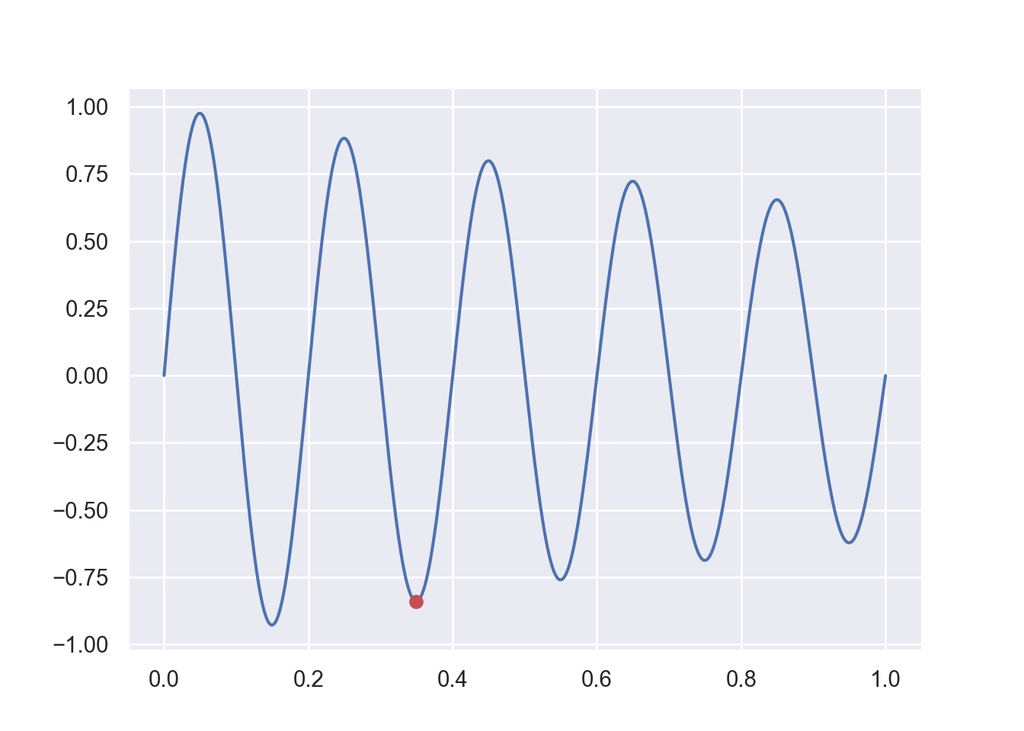

```python
import numpy as np
import seaborn as sns
sns.set(style="darkgrid")
import matplotlib.pyplot as plt
from scipy import optimize as opt  #pip install scipy --upgrade

foo = lambda x: np.exp(-.5 * x) * np.sin(10 * np.pi * x)
foo(0.5)
#> 4.768779430809241e-16
res = opt.minimize_scalar(foo, bounds = [0, 1], method = "Bounded")
res
#>  message: Solution found.
#>  success: True
#>   status: 0
#>      fun: -0.8395633414865528
#>        x: 0.34949347963438415
#>      nit: 11
#>     nfev: 11
x = np.linspace(0, 1, 1000) # let's plot something
sns.lineplot(x=x, y=foo(x))
plt.plot(res.x, res.fun, 'ro')
plt.show()
```

This example does a least squares fitting:
$$\begin{array}{ll}
\underset{a,b}{\textsf{minimize}} & \sum_{i=1}^{m} \left(y_i -
(a+bx_i)\right)^2
\end{array}$$

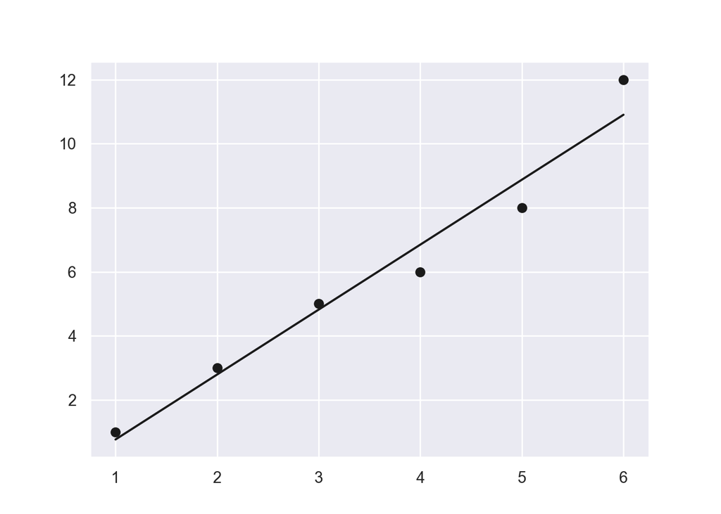

```python
import numpy as np
from scipy.optimize import minimize
import matplotlib.pyplot as plt

# data points to be fitted
x = 1 + np.arange(6)
y = np.array([1, 3, 5, 6, 8, 12])

# l2-norm error function
obj_fun = lambda param: np.sum((y - (param[0] + param[1] * x))**2)

# call solver with initial value [0, 1]
res = minimize(obj_fun, x0 = np.array([0, 1]), method = 'Nelder-Mead')
type(res)
#> <class 'scipy.optimize._optimize.OptimizeResult'>
res
#>        message: Optimization terminated successfully.
#>        success: True
#>         status: 0
#>            fun: 2.819047623875957
#>              x: [-1.267e+00  2.029e+00]
#>            nit: 64
#>           nfev: 126
#>  final_simplex: (array([[-1.267e+00,  2.029e+00],
#>                        [-1.267e+00,  2.029e+00],
#>                        [-1.267e+00,  2.029e+00]]), array([ 2.819e+00,  2.819e+00,  2.819e+00]))
plt.plot(x, y, 'ko') # plot linear regression
plt.plot(x, res.x[0] + res.x[1] * x, 'k-')
```

The next example illustrates the use of the gradient with the famous Rosenbrock banana function:
$$f(\mathbf{x}) = 100(x_2-x_1^2)^2 + (1-x_1)^2$$
with gradient
$$\nabla f(\mathbf{x}) = \left( \begin{array}{c}
-400x_1(x_2-x_1^2) -2(1-x_1)\\
200(x_2-x_1^2)
\end{array}\right)$$
with the unconstrained minimization problem
$$\begin{array}{ll}
\underset{\mathbf{x}\in \mathbf{R}^2}{\textsf{minimize}} &
100(x_2-x_1^2)^2 + (1-x_1)^2
\end{array}$$

```python
# Rosenbrock banana function and its gradient
def f_banana(x):
   return(100 * (x[1] - x[0] * x[0])**2 + (1 - x[0])**2)
def gr_banana(x):
   return(np.array([[-400 * x[0] * (x[1] - x[0] * x[0]) - 2 * (1 - x[0])],
                    [200 * (x[1] - x[0] * x[0])]]).reshape((-1)))   # reshape((-1)) converts the column matrix into a vector
res = minimize(f_banana, np.array([-1.2, 1]), method='Nelder-Mead')
res
#>        message: Optimization terminated successfully.
#>        success: True
#>         status: 0
#>            fun: 8.177661197416674e-10
#>              x: [ 1.000e+00  1.000e+00]
#>            nit: 85
#>           nfev: 159
#>  final_simplex: (array([[ 1.000e+00,  1.000e+00],
#>                        [ 1.000e+00,  1.000e+00],
#>                        [ 1.000e+00,  1.000e+00]]), array([ 8.178e-10,  1.108e-09,  1.123e-09]))
res = minimize(f_banana, np.array([-1.2, 1]), method='BFGS', jac = gr_banana)
res
#>   message: Optimization terminated successfully.
#>   success: True
#>    status: 0
#>       fun: 2.5353073555215442e-15
#>         x: [ 1.000e+00  1.000e+00]
#>       nit: 32
#>       jac: [-1.705e-06  8.233e-07]
#>  hess_inv: [[ 5.019e-01  1.003e+00]
#>             [ 1.003e+00  2.010e+00]]
#>      nfev: 39
#>      njev: 39
```

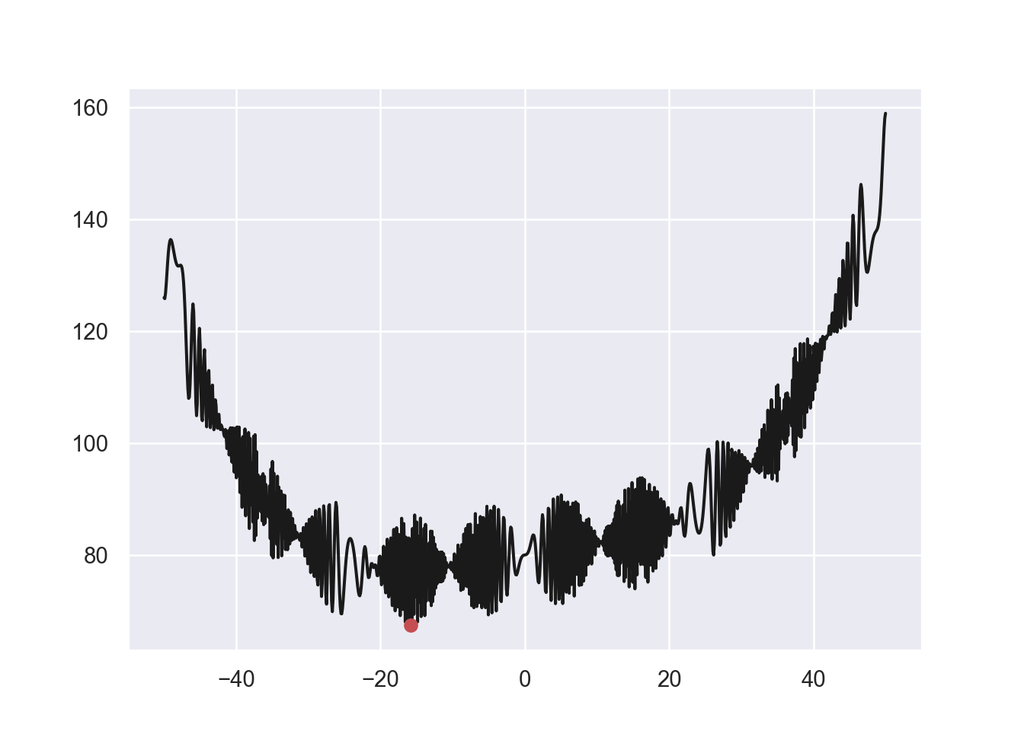

```python
from scipy import optimize as opt
# "wild" function , global minimum at about -15.81515
def f_wild(x):
    return(10*np.sin(0.3*x) * np.sin(1.3 * x**2) + 0.00001 * x**4 + 0.2 * x + 80)
t = np.linspace(-50, 50, 1000)

res = opt.basinhopping(f_wild, 50, niter = 500)
res
#>                     message: ['requested number of basinhopping iterations completed successfully']
#>                     success: False
#>                         fun: 67.46773474158658
#>                           x: [-1.582e+01]
#>                         nit: 500
#>       minimization_failures: 64
#>                        nfev: 11770
#>                        njev: 5630
#>  lowest_optimization_result:  message: Desired error not necessarily achieved due to precision loss.
#>                               success: False
#>                                status: 2
#>                                   fun: 67.46773474158658
#>                                     x: [-1.582e+01]
#>                                   nit: 3
#>                                   jac: [ 3.338e-05]
#>                              hess_inv: [[ 5.917e-05]]
#>                                  nfev: 106
#>                                  njev: 47
res = minimize(f_wild, res.x, method='BFGS') # now improve locally (typically only by a small bit):
res
#>   message: Desired error not necessarily achieved due to precision loss.
#>   success: False
#>    status: 2
#>       fun: 67.46773474158658
#>         x: [-1.582e+01]
#>       nit: 0
#>       jac: [ 3.338e-05]
#>  hess_inv: [[1]]
#>      nfev: 76
#>      njev: 32
plt.plot(t, f_wild(t), 'k-')
plt.plot(res.x, f_wild(res.x), 'ro')
```

Note that some methods accept bounds on the optimization variable via the argument `bounds`. However, make sure to verify in the [documentation](https://docs.scipy.org/doc/scipy/reference/generated/scipy.optimize.minimize.html#scipy.optimize.minimize) whether the particular method accepts bounds or not.

# Solvers for specific classes of problems

If the problem to be solved falls within a particular class of problems, such as LS, LP, MILP, QP, SOCP, or SDP, then it is much better to use a solver specific for that class.

## Least Squares (LS)

A linear least-squares (LS) problem minimizes the $\ell_2$-norm $\|\mathbf{A}\mathbf{x}-\mathbf{b}\|_2$ possibly with bounds or linear constraints. The function `scipy.optimize.lsq_linear` from scipy solves over- and underdetermined linear systems in the least-squares sense.

## Linear Programming (LP)

The package **scipy** contains the function `scipy.optimize.linprog` ([documentation](https://docs.scipy.org/doc/scipy/reference/generated/scipy.optimize.linprog.html)) to conveniently solve LPs of the form (it can also contain equality constraints):
$$\begin{array}{ll}
\underset{\mathbf{x}\in \mathbf{R}^n}{\textsf{minimize}} &
\mathbf{c}^T\mathbf{x}\\
{\textsf{subject to}} & \begin{array}[t]{l} \mathbf{A}\mathbf{x} \le
\mathbf{b}\\
\mathbf{l} \le \mathbf{x} \le \mathbf{u}.\end{array}\\
\end{array}$$

Let’s consider the following LP:
$$\begin{array}{ll}
\underset{x_0, x_1}{\textsf{minimize}} & 4 x_1 - x_0\\
{\textsf{subject to}} & \begin{array}[t]{l} x_1 - 3 x_0 \leq 6\\
x_0 + 2x_1 \leq 4\\
x_1 \geq -3 \\
-\infty \leq x_0 \leq \infty
\end{array}
\end{array}$$

```python
from scipy.optimize import linprog

c = [-1, 4]
A = [[-3, 1], [1, 2]]
b = [6, 4]
x0_bounds = (None, None)
x1_bounds = (-3, None)
res = linprog(c, A_ub=A, b_ub=b, bounds=(x0_bounds, x1_bounds), options={"disp": True})
res
#>         message: Optimization terminated successfully. (HiGHS Status 7: Optimal)
#>         success: True
#>          status: 0
#>             fun: -22.0
#>               x: [ 1.000e+01 -3.000e+00]
#>             nit: 0
#>           lower:  residual: [       inf  0.000e+00]
#>                  marginals: [ 0.000e+00  6.000e+00]
#>           upper:  residual: [       inf        inf]
#>                  marginals: [ 0.000e+00  0.000e+00]
#>           eqlin:  residual: []
#>                  marginals: []
#>         ineqlin:  residual: [ 3.900e+01  0.000e+00]
#>                  marginals: [-0.000e+00 -1.000e+00]
#>  mip_node_count: 0
#>  mip_dual_bound: 0.0
#>         mip_gap: 0.0
```

## Quadratic Programming (QP)

The package [**quadprog**](https://github.com/rmcgibbo/quadprog) contains the function `solve_qp` to conveniently solve QPs of the form:
$$\begin{array}{ll}
\underset{\mathbf{x}\in \mathbf{R}^n}{\textsf{minimize}} &
-\mathbf{a}^T\mathbf{x} + \frac{1}{2}\mathbf{x}^T\mathbf{G}\mathbf{x}\\
{\textsf{subject to}} & \mathbf{C}^T\mathbf{x} \geq \mathbf{b}\\
\end{array}$$

```python
from quadprog import solve_qp  # pip install quadprog
import numpy as np

# Set up problem:
#   minimize    -(0 5 0) x + 1/2 x^T x
#   subject to  A^T x >= b
#   with b = (-8,2,0)^T
#       (-4 2  0)
#   A = (-3 1 -2)
#       ( 0 0  1)
Gmat = np.eye(3)
avec = np.array([0., 5., 0.])
Cmat = np.array([[-4., -3., 0.],
                  [2., 1., 0.],
                  [0., -2., 1.]])
bvec = np.array([-8., 2., 0.])

# run solver
res = solve_qp(Gmat, avec, Cmat, bvec)
```

The package [**osqp**](https://osqp.org/docs/interfaces/python.html) offers a object-oriented way to solve QPs written in the following form:
$$\begin{array}{ll}
\underset{\mathbf{x}}{\mbox{minimize}} & \frac{1}{2} \mathbf{x}^T
\mathbf{P} \mathbf{x} + \mathbf{q}^T \mathbf{x} \\
\mbox{subject to} & \mathbf{l} \leq \mathbf{A} \mathbf{x} \leq
\mathbf{u}
\end{array}$$

```python
import osqp # pip install osqp
import numpy as np
import scipy as sp
from scipy import sparse

# Generate problem data
np.random.seed(1)
m = 30
n = 20
Ad = sparse.random(m, n, density=0.7, format='csc')
b = np.random.randn(m)

# OSQP data
P = sparse.block_diag([sparse.csc_matrix((n, n)), sparse.eye(m)], format='csc')
q = np.zeros(n+m)
A = sparse.vstack([
        sparse.hstack([Ad, -sparse.eye(m)]),
        sparse.hstack([sparse.eye(n), sparse.csc_matrix((n, m))])], format='csc')
l = np.hstack([b, np.zeros(n)])
u = np.hstack([b, np.ones(n)])

# Create an OSQP object
prob = osqp.OSQP()

# Setup workspace
prob.setup(P, q, A, l, u)
#> -----------------------------------------------------------------
#>            OSQP v0.6.2  -  Operator Splitting QP Solver
#>               (c) Bartolomeo Stellato,  Goran Banjac
#>         University of Oxford  -  Stanford University 2021
#> -----------------------------------------------------------------
#> problem:  variables n = 50, constraints m = 50
#>           nnz(P) + nnz(A) = 500
#> settings: linear system solver = qdldl,
#>           eps_abs = 1.0e-03, eps_rel = 1.0e-03,
#>           eps_prim_inf = 1.0e-04, eps_dual_inf = 1.0e-04,
#>           rho = 1.00e-01 (adaptive),
#>           sigma = 1.00e-06, alpha = 1.60, max_iter = 4000
#>           check_termination: on (interval 25),
#>           scaling: on, scaled_termination: off
#>           warm start: on, polish: off, time_limit: off
res = prob.solve() # Solve problem
#> iter   objective    pri res    dua res    rho        time
#>    1   0.0000e+00   2.50e+00   4.47e+02   1.00e-01   1.46e-04s
#>   75   1.6492e+01   1.58e-04   3.63e-05   1.47e+00   2.76e-04s
#>
#> status:               solved
#> number of iterations: 75
#> optimal objective:    16.4920
#> run time:             2.80e-04s
#> optimal rho estimate: 3.28e+00
```

## Second-Order Cone Programming (SOCP)

There are several packages:

- Package [**ecos-python**](https://github.com/embotech/ecos-python) provides an interface to the [Embedded COnic Solver (ECOS)](http://www.embotech.com/ECOS), a well-known, efficient, and robust C library for convex problems. Conic and equality constraints can be specified in addition to integer and boolean variable constraints for mixed-integer problems.

## Cone Programming and Semi-Definite Programming (SDP)

There are several good packages:

- Package [**Irene**](https://irene.readthedocs.io/en/latest/sdp.html) Irene was originally written to find reliable approximations for optimum value of an arbitrary optimization problem. It implements a modification of Lasserre’s SDP Relaxations based on generalized truncated moment problem to handle general optimization problems algebraically.
- Package [**mosek**](https://docs.mosek.com/9.1/pythonapi/install-interface.html) contains a Python interface to the (commercial) [MOSEK](https://www.mosek.com/) optimization library for large-scale LP, QP, and MIP problems, with emphasis on (nonlinear) conic, semidefinite, and convex tasks; academic licenses are available.
- Package [**scs**](https://github.com/cvxgrp/scs) is a numerical optimization package for solving large-scale convex cone problems, based on the paper [Conic Optimization via Operator Splitting and Homogeneous Self-Dual Embedding](http://www.stanford.edu/~boyd/papers/scs.html).

## Mixed Integer Programming

- Package [**mip**](https://docs.python-mip.com/en/latest/install.html) is a collection of Python tools for the modeling and solution of Mixed-Integer Linear programs (MIPs). It provides access to advanced solver features like cut generation, lazy constraints, MIP starts and solution pools.

# Optimization infrastructure packages

## **CVXPY** for Convex Problems

[CVXPY](https://www.cvxpy.org) is a Python package that provides an object-oriented modeling language for convex optimization, similar to CVX, CVXR, YALMIP, and Convex.jl. It allows the user to formulate convex optimization problems in a natural mathematical syntax rather than the restrictive standard form required by most solvers. The user specifies an objective and set of constraints by combining constants, variables, and parameters using a library of functions with known mathematical properties. CVXR then applies signed disciplined convex programming (DCP) to verify the problem’s convexity. Once verified, the problem is converted into standard conic form using graph implementations and passed to a cone solver such as **ECOS** or **SCS**. See [CVX tutorials](https://www.cvxpy.org/tutorial/index.html) for details. Let’s see now several examples.

**Least squares** – Let’s start with a simple LS example:
$$\begin{array}{ll}
\underset{\boldsymbol{\beta}}{\textsf{minimize}} & \|\mathbf{y} -
\mathbf{X}\boldsymbol{\beta}\|_2^2\\
\end{array}$$

Let’s first solve it via Scipy `lsq_linear`:

```python
import numpy as np
from scipy.optimize import lsq_linear

# generate data
m = 100
n = 10
beta_true = np.arange(10) - 4
X = np.random.normal(size=n*m).reshape((m,-1))
y = X @ beta_true + np.random.normal(size=m)
# estimate x
res = lsq_linear(X, y)
res
#>        message: The unconstrained solution is optimal.
#>        success: True
#>         status: 3
#>            fun: [-1.111e+00  1.494e+00 ...  2.154e-01 -6.792e-01]
#>              x: [-4.016e+00 -3.009e+00 -2.134e+00 -6.944e-01 -5.416e-02
#>                   7.346e-01  1.870e+00  3.207e+00  3.844e+00  5.001e+00]
#>            nit: 0
#>           cost: 50.554985548735786
#>     optimality: 6.257216966787382e-13
#>    active_mask: [ 0.000e+00  0.000e+00  0.000e+00  0.000e+00  0.000e+00
#>                   0.000e+00  0.000e+00  0.000e+00  0.000e+00  0.000e+00]
#>  unbounded_sol: (array([-4.016e+00, -3.009e+00, -2.134e+00, -6.944e-01,
#>                        -5.416e-02,  7.346e-01,  1.870e+00,  3.207e+00,
#>                         3.844e+00,  5.001e+00]), array([ 1.011e+02]), 10, array([ 1.224e+01,  1.170e+01,  1.101e+01,  1.035e+01,
#>                         1.006e+01,  9.406e+00,  9.177e+00,  9.033e+00,
#>                         7.789e+00,  7.247e+00]))
```

Now let’s do it with **CVXPY**:

```python
import cvxpy as cp  # pip install cvxpy
import numpy as np

# define variable
beta = cp.Variable(n)
# define objective
objective = cp.Minimize(cp.sum_squares(X @ beta - y))
# create problem
prob = cp.Problem(objective)
# solve it!
result = prob.solve()
beta.value
#> array([-4.01608366, -3.00908591, -2.13356382, -0.69438355, -0.05416262,
#>         0.73455804,  1.86975671,  3.20690015,  3.84395209,  5.00103773])
```

We can now easily add a contraint to solve a nonnegative LS:

```python
constraints = [beta >= 0]
prob = cp.Problem(objective, constraints)
result = prob.solve()
beta.value
#> array([-5.26234528e-17, -5.73508451e-17, -7.18364453e-17, -1.11603668e-16,
#>         4.05790128e-01,  1.60249957e+00,  1.93370680e+00,  2.53939243e+00,
#>         3.92161170e+00,  5.76468454e+00])
```

We can add other constraints:

```python
constraint1 = beta[2] + beta[3] <= 0
A = np.diag(np.concatenate([np.array([1, 0, 0]), np.array([1] * 7)]))
A
#> array([[1, 0, 0, 0, 0, 0, 0, 0, 0, 0],
#>        [0, 0, 0, 0, 0, 0, 0, 0, 0, 0],
#>        [0, 0, 0, 0, 0, 0, 0, 0, 0, 0],
#>        [0, 0, 0, 1, 0, 0, 0, 0, 0, 0],
#>        [0, 0, 0, 0, 1, 0, 0, 0, 0, 0],
#>        [0, 0, 0, 0, 0, 1, 0, 0, 0, 0],
#>        [0, 0, 0, 0, 0, 0, 1, 0, 0, 0],
#>        [0, 0, 0, 0, 0, 0, 0, 1, 0, 0],
#>        [0, 0, 0, 0, 0, 0, 0, 0, 1, 0],
#>        [0, 0, 0, 0, 0, 0, 0, 0, 0, 1]])
constraint2 = A @ beta >= 0

# define problem and solve it
prob = cp.Problem(objective, constraints = [constraint1, constraint2])
result = prob.solve()
beta.value
#> array([-8.12144594e-17, -2.55930726e+00, -2.38179431e+00, -7.59330506e-18,
#>         5.69530272e-01,  1.56146521e+00,  1.83898696e+00,  2.49285673e+00,
#>         3.68068355e+00,  5.85268505e+00])
```

**Robust Huber regression** – Let’s consider another simple example of robust regression:
$$\begin{array}{ll}
\underset{\boldsymbol{\beta}}{\textsf{minimize}} & \sum_{i=1}^m
\phi(y_i - \mathbf{x}_i^T\boldsymbol{\beta})
\end{array}$$
where
$$\phi(u) = \begin{cases}
u^2 & \text{if }|u| \le M \\
2Mu-M^2 & \text{if }|u| > M
\end{cases}$$

```python
M = 0.1
beta = cp.Variable(n)
obj = cp.sum(cp.huber(y - X @ beta, M))
cp.Problem(cp.Minimize(obj)).solve()
#> 15.078118013886765
beta.value
#> array([-4.17042853, -3.04044983, -2.10513397, -0.71206119, -0.01068557,
#>         0.76251828,  1.8334574 ,  3.23198934,  3.77406989,  4.90310484])
```

**Elastic net regularization** – We will now solve the problem:
$$\begin{array}{ll}
\underset{\boldsymbol{\beta}}{\textsf{minimize}} &
\frac{1}{2m}\|\mathbf{y} - \mathbf{X}\boldsymbol{\beta}\|_2^2
+ \lambda \left( (1-\alpha)\|\boldsymbol{\beta}\|_2^2 + \alpha\|
\boldsymbol{\beta} \|_1 \right)
\end{array}$$

```python
# define the regularization term
def elastic_reg(beta, lmd = 0, alpha = 0):
  ridge = (1 - alpha) * cp.sum(beta ** 2)
  lasso = alpha * cp.norm(beta, 1)
  return lmd * (lasso + ridge)

# define problem and solve it
alpha = 0.5
lmd = 0.5
obj = cp.sum((y - X @ beta)**2) + elastic_reg(beta, lmd, alpha)
cp.Problem(cp.Minimize(obj)).solve()
#> 128.26245852169413
beta.value
#> array([-4.00380815, -2.99831083, -2.12711484, -0.69208925, -0.05285668,
#>         0.73604469,  1.86351502,  3.19408019,  3.83259749,  4.9906979 ])
```

**Sparse inverse covariance estimation** – Consider the matrix-valued convex problem:
$$\begin{array}{ll}
\underset{\mathbf{X}}{\textsf{maximize}} &
\textsf{logdet}(\mathbf{X}) - \textsf{Tr}(\mathbf{X}\mathbf{S})\\
\textsf{subject to} & \mathbf{X} \succeq \mathbf{0}, \qquad
\sum_{i=1}^n\sum_{j=1}^n\left|X_{ij}\right| \le \alpha
\end{array}$$

```python
n = 3
np.random.seed(1)
S = np.random.randn(n, n)
X = cp.Variable((n, n), PSD=True)
obj = cp.log_det(X) - cp.trace(X @ S)
alpha = 1
constr = [cp.sum(cp.abs(X)) <= alpha]
cp.Problem(cp.Maximize(obj), constr).solve()
#> -4.185810217910456
X.value
#> array([[ 2.64619430e-01,  1.06485547e-07, -3.78005567e-08],
#>        [ 1.06485547e-07,  3.31118028e-01,  8.96471856e-08],
#>        [-3.78005567e-08,  8.96471856e-08,  4.04255113e-01]])
np.linalg.eig(X.value)[0] # compute the eigenvalues of X to verify it is PD
#> array([0.26461943, 0.33111803, 0.40425511])
```

# Conclusion

The solvers available in Python are more than enough for the purposes of our course. The following steps are suggested:

- If the problem is convex, then start with **CVXPY** for initial tests.
- If faster speed is required, then if the problem belongs to one of the well defined classes, such as LP, MILP, QP, SOCP, or SDP, use a solver specific for that class (for example, for LPs we recommend **scipy.optimize.linprog** and for QPs **quadprog.solve_qp**).
- However, if the problem does not fit any class, then one has to use a general solver for nonlinear optimization using the function `minimize`. In that sense, only a local solution is guaranteed. If a global solver is required, one may use the [global optimization functions](https://docs.scipy.org/doc/scipy/reference/optimize.html#global-optimization) available in Scipy.